# Exploring the BRFSS data

## Setup

### Load packages

```r
library(ggplot2)
library(dplyr)
```

### Load data

```r
load("brfss2013.RData")
```

## Part 1: Data

Any findings from The Behavioral Risk Factor Surveillance System 2013 data set can be generalized to the population of non-institutionalized adults ( 18 years old and older), who live in the USA, District of Columbia, Guam, and Puerto Rico. This is because a random sample of phone interviews was conducted in these regions. There is a potential for non-response bias in this sampling scheme, because there is a chance for a non-random fraction of sampled households to not participate in the study.

The results of this exploratory data analysis are not causal for the above stated population, because a observational study was preformed, not a experiment.

## Part 2: Research questions

**Research quesion 1:**

Is there a relationship between what state a responder lives in and the average number of sugary drinks they have consumed in the past 30 days?

This question would be of interesting for soda companies; they could use the data to help drive marketing campaigns.

**Research quesion 2:**

Is there a relationship between the amount of time sleeping, number of poor mental health days, and gender of the respondent?

I was always told that good nights of sleep improved mood, and I would be interested in what story the data provides.

**Research quesion 3:**

Is there a difference between men and women’s sugary drink consumption in the state of Kentucky?

For marketing reasons knowing the difference, if there is one, between habits of men and women is important. Since gender is a very natural divider.

## Part 3: Exploratory data analysis

**Research quesion 1:**

The reporting of responses on sugary drinks drank in the past 30 days creates a very interesting distribution, as seen in the next four graphs.

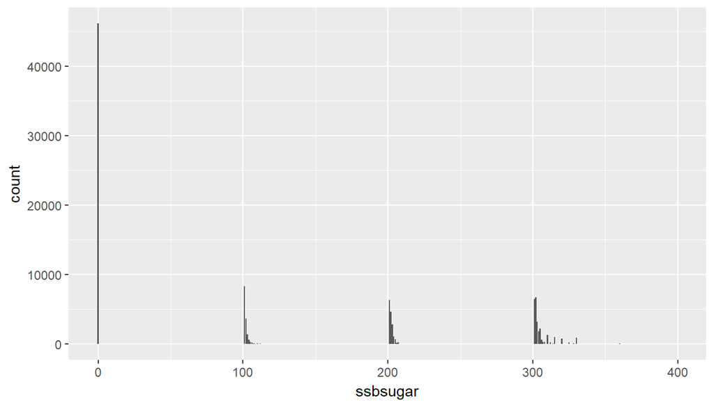

```r
ggplot(data = brfss2013, mapping = aes(x = ssbsugar)) + geom_bar()
```

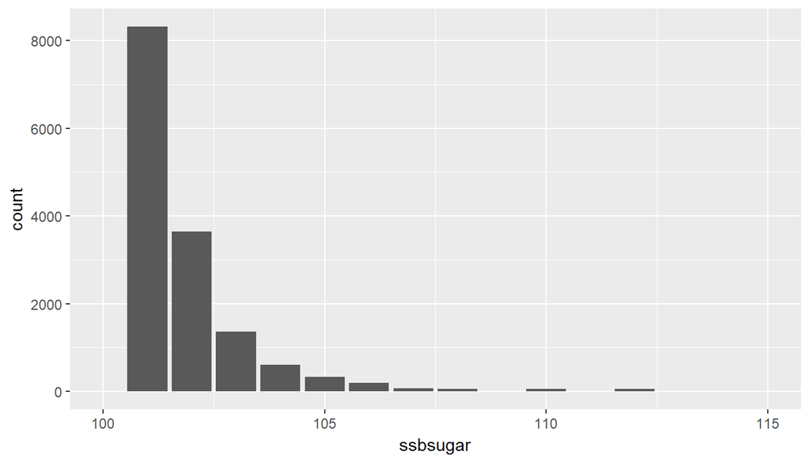

```r
ggplot(data = brfss2013, mapping = aes(x = ssbsugar)) + geom_bar() + xlim(100, 115)
```

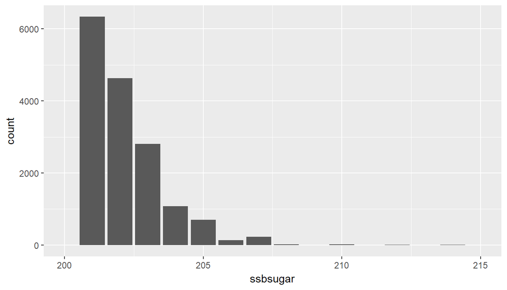

```r
ggplot(data = brfss2013, mapping = aes(x = ssbsugar)) + geom_bar() + xlim(200, 215)
```

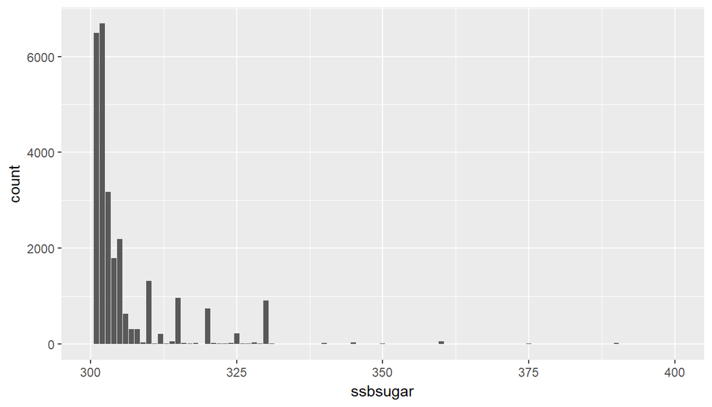

```r
ggplot(data = brfss2013, mapping = aes(x = ssbsugar)) + geom_bar() + xlim(300, 400)
```

This format can inform us on the pyscology of peoples responces, but may cause confusion on raw number of sugary drinks had. So I have condenced them into a single scale.

```r
sugarbrfss <- brfss2013 %>%
  filter(!is.na(ssbsugar)) %>%
  select(X_state, ssbsugar, sex)

sugarbrfss <- sugarbrfss %>%
  mutate(
    sugarin30days = case_when(
          ssbsugar - ssbsugar%%100 == 100 ~ as.double((ssbsugar%%100) * 30),
          ssbsugar - ssbsugar%%100 == 200 ~ as.double(((ssbsugar%%100)/7) * 30),
          ssbsugar - ssbsugar%%100 == 300 ~ as.double(ssbsugar%%100),
          TRUE ~ 0
                              )
        )
```

There is a massive outlier in the data, of 1200 drinks in 30 days, which is why the following graph is bounded.

```r
sugarbrfss %>%
  summarise(MeanSug = mean(sugarin30days), meadSug = median(sugarin30days))
```

```
##    MeanSug meadSug
## 1 10.89798       1
```

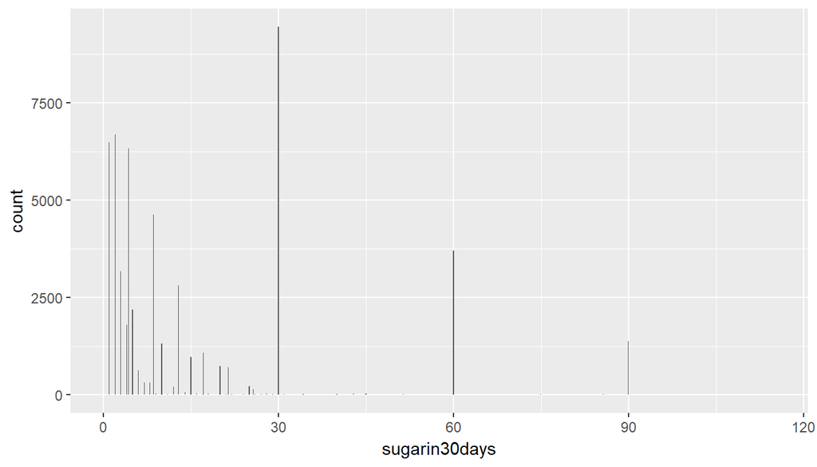

```r
ggplot(data = sugarbrfss, mapping = aes(x = sugarin30days)) + geom_bar() + xlim(0.1, 115)
```

```r
sugarbrfss %>%
  select(X_state, ssbsugar) %>%
  summary()
```

```
##            X_state         ssbsugar
##  Minnesota     :12774   Min.   :  0
##  Maryland      :11841   1st Qu.:  0
##  Utah          :11499   Median :101
##  Kentucky      : 9762   Mean   :124
##  South Carolina: 9699   3rd Qu.:301
##  Connecticut   : 6831   Max.   :399
##  (Other)       :40789
```

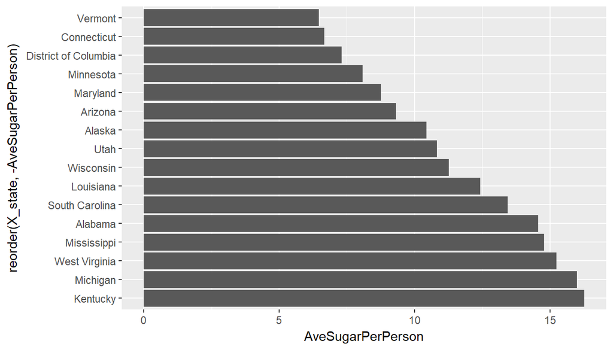

```r
sugarbrfss %>%
  group_by(X_state) %>%
  summarise(AveSugarPerPerson = mean(sugarin30days)) %>%
  ggplot(aes(x = reorder(X_state, -AveSugarPerPerson), y = AveSugarPerPerson)) + geom_bar(stat="identity") + coord_flip()
```

It is very surprizing how few states there is complete data for. There does not seem to be any states which are outliers for the number of drinks consumed in 30 days.

**Research quesion 2:**

To clean the data for analysis, NA values and values which must be data entery mistakes are removed. There should not be any values larger than 24 hours for sleep time, because there are only 24 hours in a day, and no more than 30 bad mental health days in 30 days.

```r
SleepTime <- brfss2013 %>%
               filter(!is.na(sleptim1) & !is.na(menthlth) & !is.na(sex)& sleptim1 <= 24 & menthlth <= 30) %>%
               select(sleptim1, menthlth, sex)
summary(SleepTime)
```

```
##     sleptim1         menthlth         sex
##  Min.   : 1.000   Min.   : 0.00   Male  :195925
##  1st Qu.: 6.000   1st Qu.: 0.00   Female:280688
##  Median : 7.000   Median : 0.00
##  Mean   : 7.052   Mean   : 3.34
##  3rd Qu.: 8.000   3rd Qu.: 2.00
##  Max.   :24.000   Max.   :30.00
```

```r
SleepTime %>%
  group_by(sex) %>%
  summarize(MeanSleep=mean(sleptim1), MeanMHealth = mean(menthlth) )
```

```
## # A tibble: 2 x 3
##   sex    MeanSleep MeanMHealth
##   <fct>      <dbl>       <dbl>
## 1 Male        7.03        2.75
## 2 Female      7.07        3.75
```

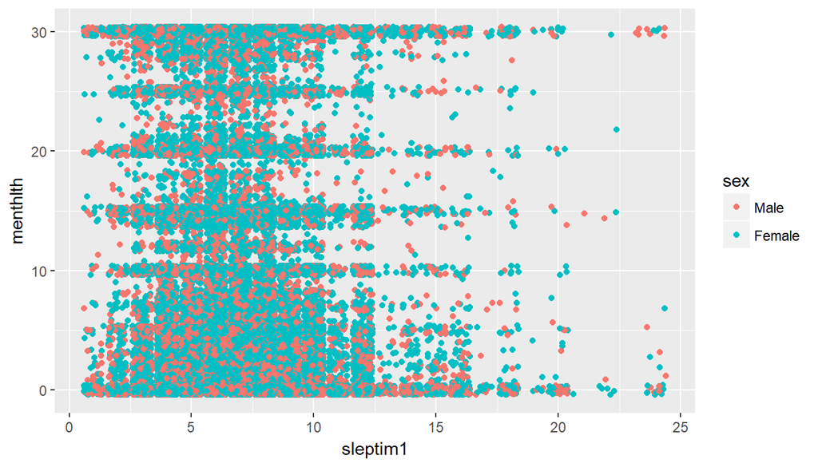

```r
SleepTime %>%
  ggplot(aes(x = sleptim1, y = menthlth, color = sex)) + geom_point(position = "jitter")
```

**Research quesion 3:**

```r
sugarbrfss %>%
  filter(X_state == "Kentucky") %>%
  group_by(sex) %>%
  summarize(MeanSugar = mean(sugarin30days), MedianSugar = median(sugarin30days), Count = n())
```

```
## # A tibble: 2 x 4
##   sex    MeanSugar MedianSugar Count
##   <fct>      <dbl>       <dbl> <int>
## 1 Male        20.3        4.29  3397
## 2 Female      14.1        2     6365
```

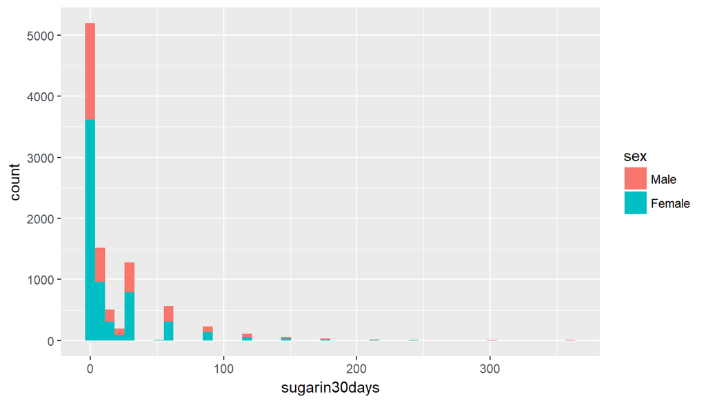

```r
sugarbrfss %>%
  filter(X_state == "Kentucky") %>%
  ggplot(aes(x = sugarin30days, fill = sex))  + geom_histogram(bins = 50)
```

My first thought was that the male outlier value near 400 drinks in 30 days, was what drived the difference between men and women mean values. With the meadian values relatively close, I feel that my first thought maybe correct. Also there are about twice as many female responces which could allow for a tighter distrubution, seen as a smaller difference between mean and median.